# Car Price Prediction

### 1. Import packages and data

#### 1.1 Import packages

```python
#Import libraries
import pandas as pd
import numpy as np
import matplotlib.pyplot as plt
import seaborn as sns
import os
import warnings
from matplotlib.ticker import ScalarFormatter

#General settings for the notebook
%matplotlib inline
pd.set_option("display.max_rows", None,"display.max_columns", None)
warnings.simplefilter(action='ignore')
plt.style.use('seaborn')
```

#### 1.2 Import data

```python
df = pd.read_csv('/content/car_price_prediction.csv')

df.head(10)
```

|  | ID | Price | Levy | Manufacturer | Model | Prod. year | Category | Leather interior | Fuel type | Engine volume | Mileage | Cylinders | Gear box type | Drive wheels | Doors | Wheel | Color | Airbags |
| --- | --- | --- | --- | --- | --- | --- | --- | --- | --- | --- | --- | --- | --- | --- | --- | --- | --- | --- |
| 0 | 45654403 | 13328 | 1399 | LEXUS | RX 450 | 2010 | Jeep | Yes | Hybrid | 3.5 | 186005 km | 6.0 | Automatic | 4x4 | 04-May | Left wheel | Silver | 12 |
| 1 | 44731507 | 16621 | 1018 | CHEVROLET | Equinox | 2011 | Jeep | No | Petrol | 3 | 192000 km | 6.0 | Tiptronic | 4x4 | 04-May | Left wheel | Black | 8 |
| 2 | 45774419 | 8467 | - | HONDA | FIT | 2006 | Hatchback | No | Petrol | 1.3 | 200000 km | 4.0 | Variator | Front | 04-May | Right-hand drive | Black | 2 |
| 3 | 45769185 | 3607 | 862 | FORD | Escape | 2011 | Jeep | Yes | Hybrid | 2.5 | 168966 km | 4.0 | Automatic | 4x4 | 04-May | Left wheel | White | 0 |
| 4 | 45809263 | 11726 | 446 | HONDA | FIT | 2014 | Hatchback | Yes | Petrol | 1.3 | 91901 km | 4.0 | Automatic | Front | 04-May | Left wheel | Silver | 4 |
| 5 | 45802912 | 39493 | 891 | HYUNDAI | Santa FE | 2016 | Jeep | Yes | Diesel | 2 | 160931 km | 4.0 | Automatic | Front | 04-May | Left wheel | White | 4 |
| 6 | 45656768 | 1803 | 761 | TOYOTA | Prius | 2010 | Hatchback | Yes | Hybrid | 1.8 | 258909 km | 4.0 | Automatic | Front | 04-May | Left wheel | White | 12 |
| 7 | 45816158 | 549 | 751 | HYUNDAI | Sonata | 2013 | Sedan | Yes | Petrol | 2.4 | 216118 km | 4.0 | Automatic | Front | 04-May | Left wheel | Grey | 12 |
| 8 | 45641395 | 1098 | 394 | TOYOTA | Camry | 2014 | Sedan | Yes | Hybrid | 2.5 | 398069 km | 4.0 | Automatic | Front | 04-May | Left wheel | Black | 12 |
| 9 | 45756839 | 26657 | - | LEXUS | RX 350 | 2007 | Jeep | Yes | Petrol | 3.5 | 128500 km | 6.0 | Automatic | 4x4 | 04-May | Left wheel | Silver | 12 |

```python
len(df.columns)
```

```
18
```

```python
df.info()
```

```
<class 'pandas.core.frame.DataFrame'>
RangeIndex: 19237 entries, 0 to 19236
Data columns (total 18 columns):
 #   Column            Non-Null Count  Dtype
---  ------            --------------  -----
 0   ID                19237 non-null  int64
 1   Price             19237 non-null  int64
 2   Levy              19237 non-null  object
 3   Manufacturer      19237 non-null  object
 4   Model             19237 non-null  object
 5   Prod. year        19237 non-null  int64
 6   Category          19237 non-null  object
 7   Leather interior  19237 non-null  object
 8   Fuel type         19237 non-null  object
 9   Engine volume     19237 non-null  object
 10  Mileage           19237 non-null  object
 11  Cylinders         19237 non-null  float64
 12  Gear box type     19237 non-null  object
 13  Drive wheels      19237 non-null  object
 14  Doors             19237 non-null  object
 15  Wheel             19237 non-null  object
 16  Color             19237 non-null  object
 17  Airbags           19237 non-null  int64
dtypes: float64(1), int64(4), object(13)
memory usage: 2.6+ MB
```

#### 1.2 Cleaning data

```python
#Let's start with checking for missing values
df.isnull().sum() #
```

```
ID                  0
Price               0
Levy                0
Manufacturer        0
Model               0
Prod. year          0
Category            0
Leather interior    0
Fuel type           0
Engine volume       0
Mileage             0
Cylinders           0
Gear box type       0
Drive wheels        0
Doors               0
Wheel               0
Color               0
Airbags             0
dtype: int64
```

As there aren't any missing value for any column we will have an overview on the data

```python
df.describe()
```

|  | ID | Price | Prod. year | Cylinders | Airbags |
| --- | --- | --- | --- | --- | --- |
| count | 1.923700e+04 | 1.923700e+04 | 19237.000000 | 19237.000000 | 19237.000000 |
| mean | 4.557654e+07 | 1.855593e+04 | 2010.912824 | 4.582991 | 6.582627 |
| std | 9.365914e+05 | 1.905813e+05 | 5.668673 | 1.199933 | 4.320168 |
| min | 2.074688e+07 | 1.000000e+00 | 1939.000000 | 1.000000 | 0.000000 |
| 25% | 4.569837e+07 | 5.331000e+03 | 2009.000000 | 4.000000 | 4.000000 |
| 50% | 4.577231e+07 | 1.317200e+04 | 2012.000000 | 4.000000 | 6.000000 |
| 75% | 4.580204e+07 | 2.207500e+04 | 2015.000000 | 4.000000 | 12.000000 |
| max | 4.581665e+07 | 2.630750e+07 | 2020.000000 | 16.000000 | 16.000000 |

### 2. Exploratory Data Analysis

#### 2.1 Univariate Analysis

```
['Leather interior', 'Fuel type', 'Gear box type', 'Drive wheels', 'Doors', 'Wheel']
```

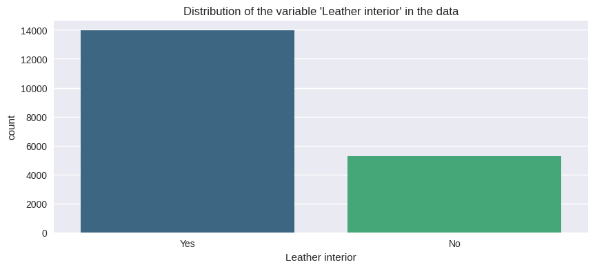

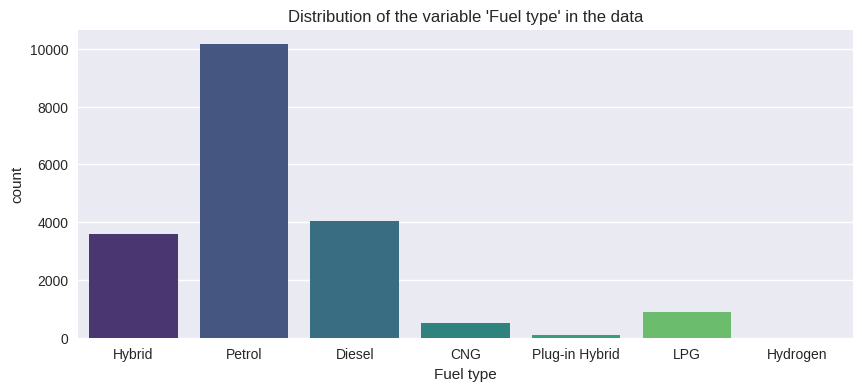

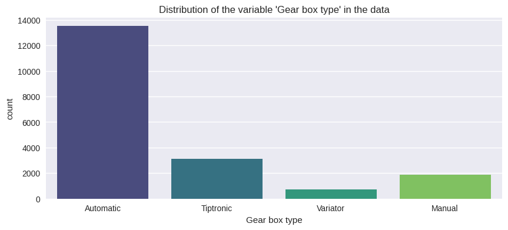

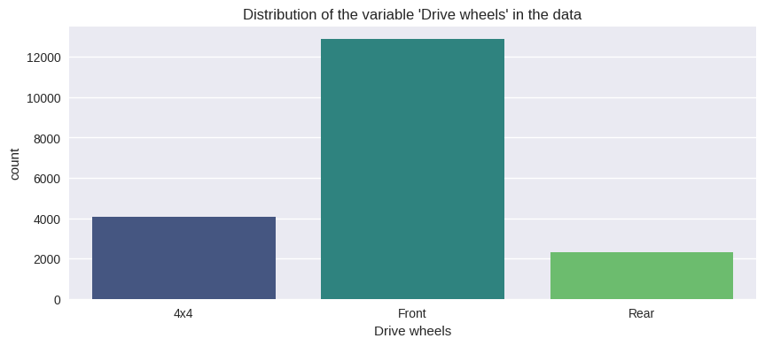

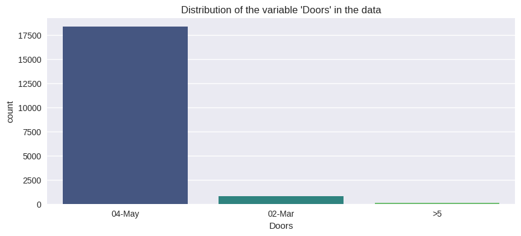

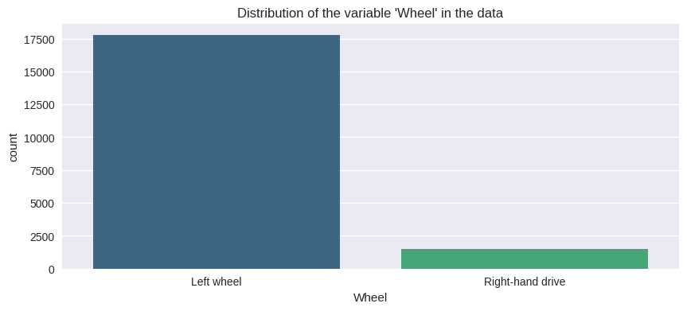

```python
col_few_unique_values =  [col for col in df.columns if df[col].nunique() < 10]
print(col_few_unique_values)

for col in col_few_unique_values:
  fig = plt.figure(figsize=[10,4])
  sns.countplot(x=col, data=df,palette='viridis')
  plt.title("Distribution of the variable '"+col+"' in the data")
  plt.show()
```

Now let's have a look on numeric columns

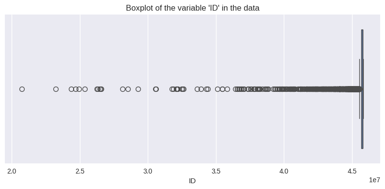

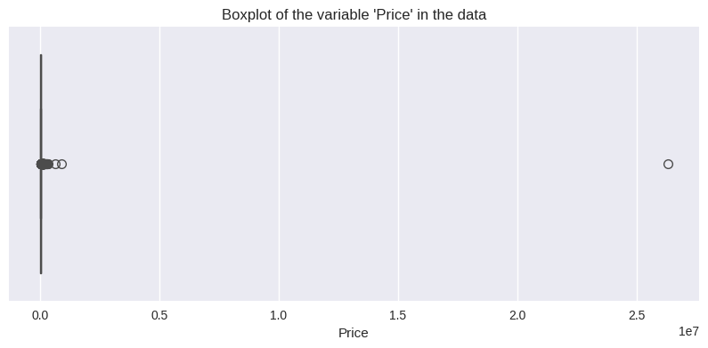

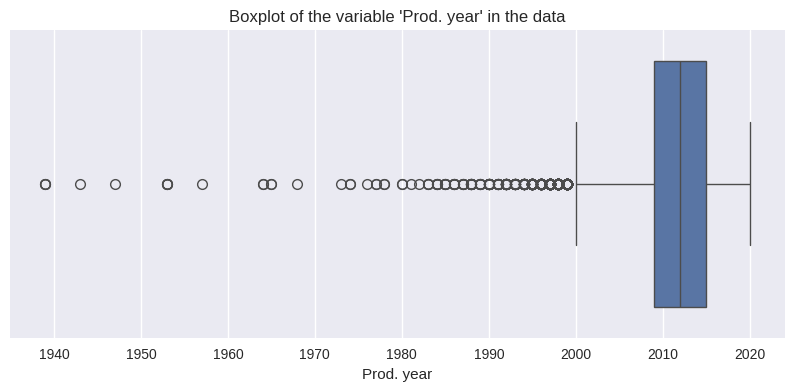

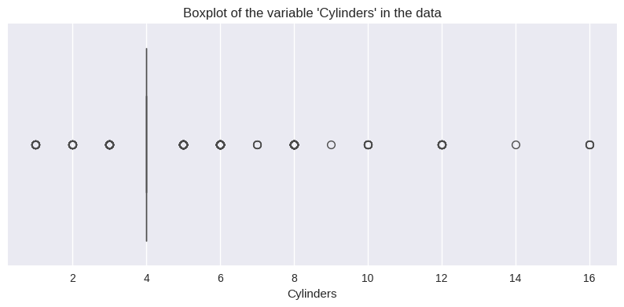

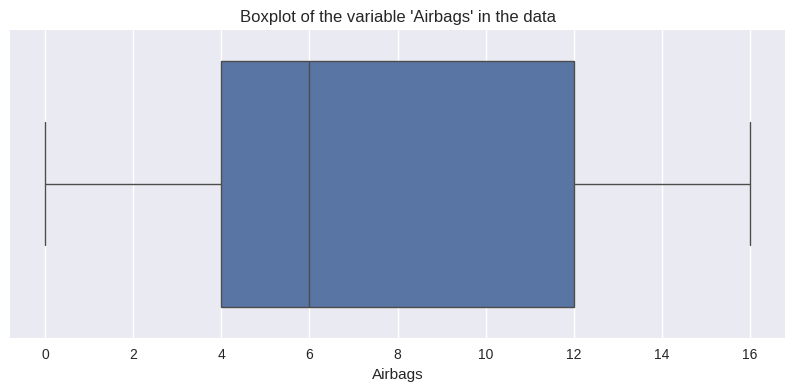

```python
numerical_columns = df.select_dtypes(include='number').columns


for col in numerical_columns:
  fig = plt.figure(figsize=[10,4])
  sns.boxplot(x=col, data=df)
  plt.title("Boxplot of the variable '"+col+"' in the data")
  plt.show()
```

#### 2.2 Multivariate Analysis

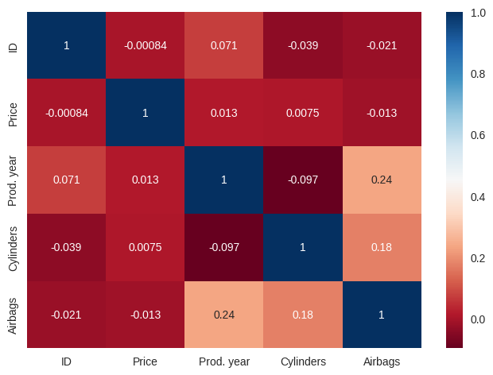

```python
df_numerical = df[numerical_columns]

sns.heatmap(df_numerical.corr(), annot=True, cmap="RdBu")
plt.show()
```

Now let's have a look on the distribution of the prices depending on the values of the categorical columns

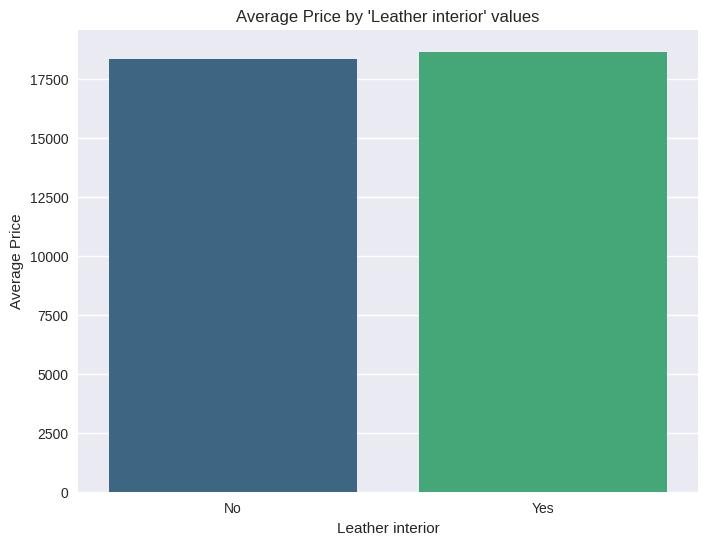

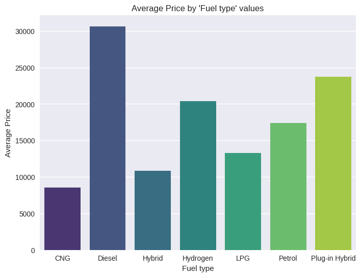

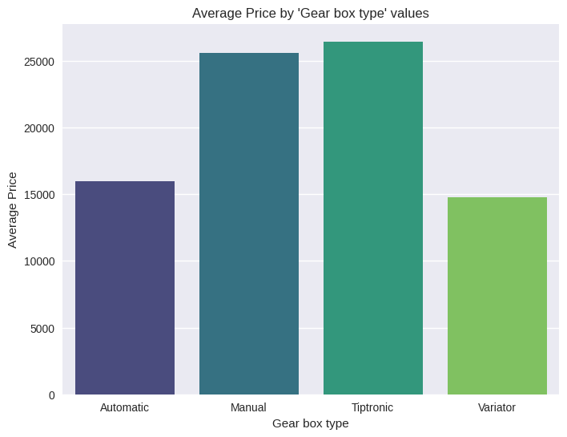

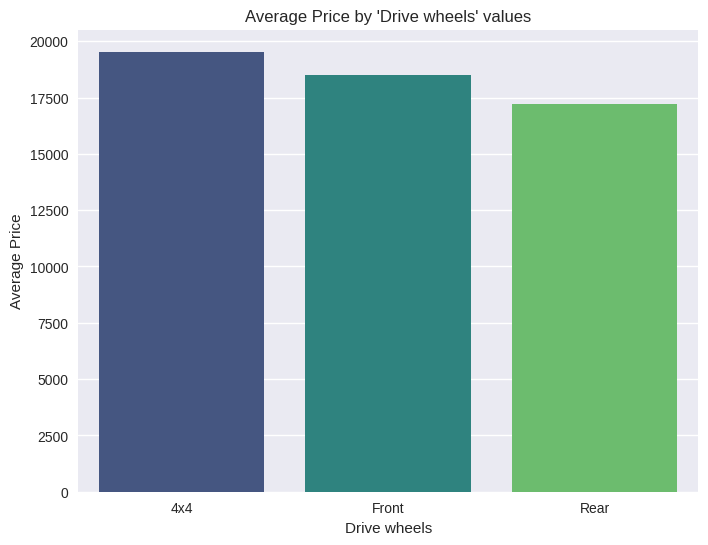

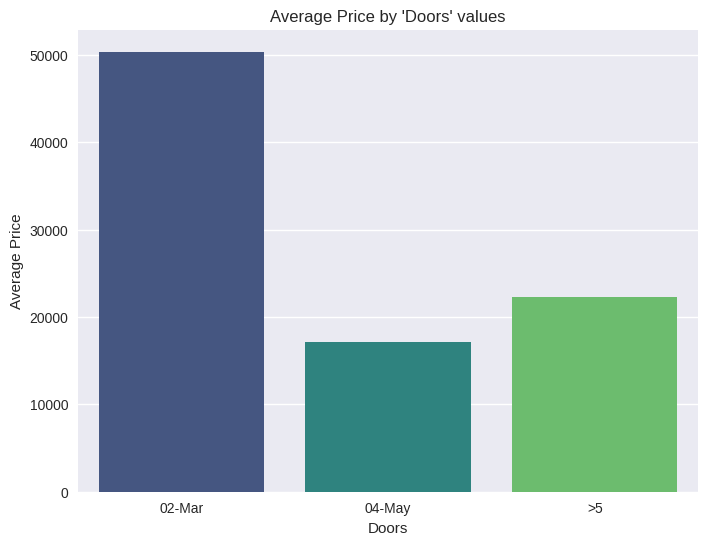

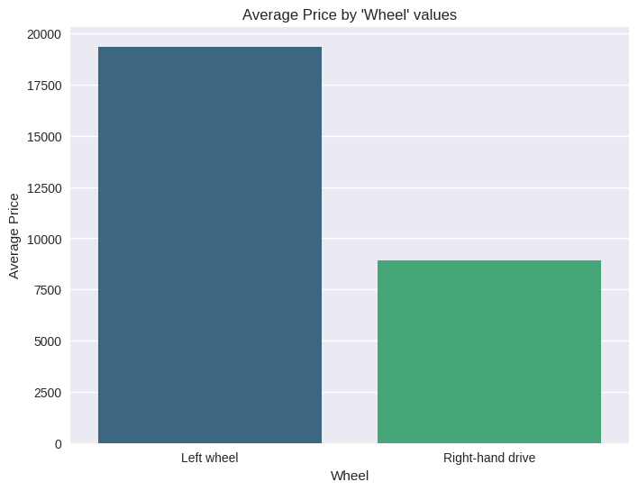

```python
for col in col_few_unique_values:
  mean_price = df.groupby(col)['Price'].mean().reset_index()
  plt.figure(figsize=(8, 6))
  sns.barplot(x=col, y='Price', data=mean_price, palette='viridis')
  plt.xlabel(col)
  plt.ylabel('Average Price')
  plt.title("Average Price by '"+col+"' values")
  plt.show()
```

And finally let's see the prices depending on the numerical columns

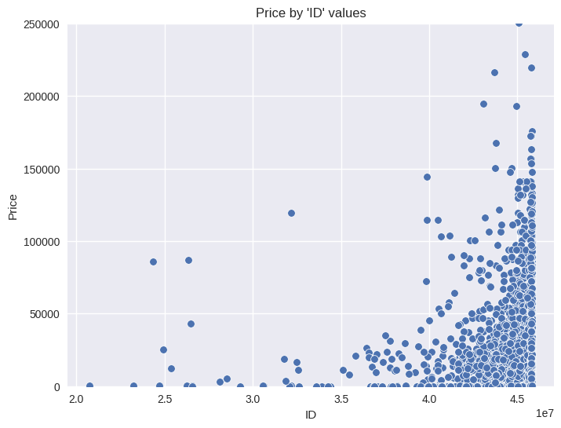

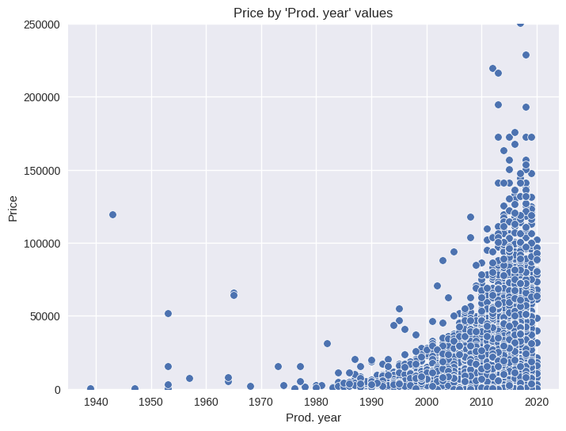

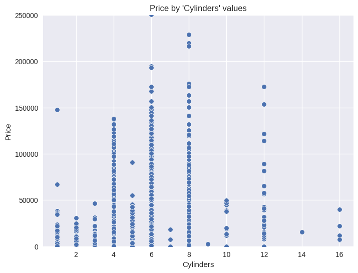

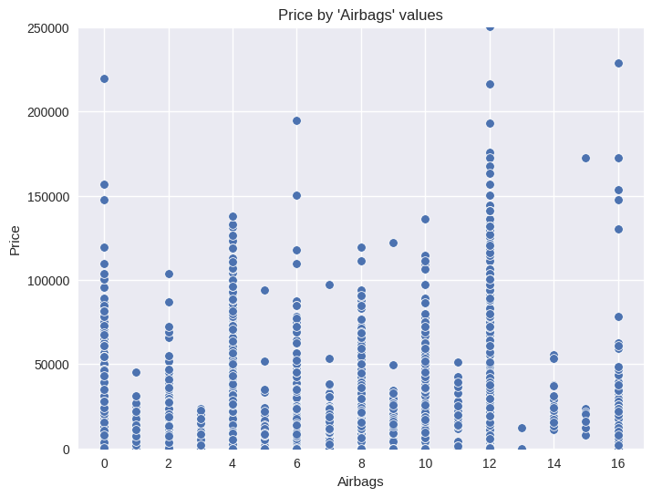

```python
for col in numerical_columns:
  if col != "Price" :
      plt.figure(figsize=(8, 6))
      sns.scatterplot(x=col, y='Price', data=df, palette='viridis')
      plt.xlabel(col)
      plt.ylabel('Price')
      plt.title("Price by '"+col+"' values")
      plt.ylim(0, 250000)
      plt.show()
```

### 3. Predicting cars prices

```python
# Converting categorical variables to dummies
for col in col_few_unique_values:
    df = pd.get_dummies(df, columns=[col], prefix=col)
```

```python
df.head(10)
```

|  | ID | Price | Levy | Manufacturer | Model | Prod. year | Category | Engine volume | Mileage | Cylinders | Color | Airbags | Leather interior_No | Leather interior_Yes | Fuel type_CNG | Fuel type_Diesel | Fuel type_Hybrid | Fuel type_Hydrogen | Fuel type_LPG | Fuel type_Petrol | Fuel type_Plug-in Hybrid | Gear box type_Automatic | Gear box type_Manual | Gear box type_Tiptronic | Gear box type_Variator | Drive wheels_4x4 | Drive wheels_Front | Drive wheels_Rear | Doors_02-Mar | … |
| --- | --- | --- | --- | --- | --- | --- | --- | --- | --- | --- | --- | --- | --- | --- | --- | --- | --- | --- | --- | --- | --- | --- | --- | --- | --- | --- | --- | --- | --- | --- |
| 0 | 45654403 | 13328 | 1399 | LEXUS | RX 450 | 2010 | Jeep | 3.5 | 186005 km | 6.0 | Silver | 12 | False | True | False | False | True | False | False | False | False | True | False | False | False | True | False | False | False | … |
| 1 | 44731507 | 16621 | 1018 | CHEVROLET | Equinox | 2011 | Jeep | 3 | 192000 km | 6.0 | Black | 8 | True | False | False | False | False | False | False | True | False | False | False | True | False | True | False | False | False | … |
| 2 | 45774419 | 8467 | - | HONDA | FIT | 2006 | Hatchback | 1.3 | 200000 km | 4.0 | Black | 2 | True | False | False | False | False | False | False | True | False | False | False | False | True | False | True | False | False | … |
| 3 | 45769185 | 3607 | 862 | FORD | Escape | 2011 | Jeep | 2.5 | 168966 km | 4.0 | White | 0 | False | True | False | False | True | False | False | False | False | True | False | False | False | True | False | False | False | … |
| 4 | 45809263 | 11726 | 446 | HONDA | FIT | 2014 | Hatchback | 1.3 | 91901 km | 4.0 | Silver | 4 | False | True | False | False | False | False | False | True | False | True | False | False | False | False | True | False | False | … |
| 5 | 45802912 | 39493 | 891 | HYUNDAI | Santa FE | 2016 | Jeep | 2 | 160931 km | 4.0 | White | 4 | False | True | False | True | False | False | False | False | False | True | False | False | False | False | True | False | False | … |
| 6 | 45656768 | 1803 | 761 | TOYOTA | Prius | 2010 | Hatchback | 1.8 | 258909 km | 4.0 | White | 12 | False | True | False | False | True | False | False | False | False | True | False | False | False | False | True | False | False | … |
| 7 | 45816158 | 549 | 751 | HYUNDAI | Sonata | 2013 | Sedan | 2.4 | 216118 km | 4.0 | Grey | 12 | False | True | False | False | False | False | False | True | False | True | False | False | False | False | True | False | False | … |
| 8 | 45641395 | 1098 | 394 | TOYOTA | Camry | 2014 | Sedan | 2.5 | 398069 km | 4.0 | Black | 12 | False | True | False | False | True | False | False | False | False | True | False | False | False | False | True | False | False | … |
| 9 | 45756839 | 26657 | - | LEXUS | RX 350 | 2007 | Jeep | 3.5 | 128500 km | 6.0 | Silver | 12 | False | True | False | False | False | False | False | True | False | True | False | False | False | True | False | False | False | … |

We will also modify the variable "Manufacturer" to get a 3 values categorical variable :

```python
# Définir les mappings pour chaque catégorie
low = [
    'CHEVROLET', 'FORD', 'HYUNDAI', 'OPEL', 'RENAULT', 'NISSAN', 'DAEWOO', 'KIA',
    'MITSUBISHI', 'SSANGYONG', 'MAZDA', 'GMC', 'FIAT', 'SUZUKI', 'VAZ', 'GAZ',
    'CITROEN', 'ISUZU', 'SKODA', 'DAIHATSU', 'BUICK', 'PEUGEOT', 'SEAT', 'LANCIA',
    'MOSKVICH', 'PONTIAC', 'SATURN', 'GREATWALL'
]

middle = [
    'HONDA', 'TOYOTA', 'VOLKSWAGEN', 'JEEP', 'SUBARU', 'INFINITI', 'ACURA', 'LINCOLN',
    'DODGE', 'CHRYSLER', 'MINI', 'HAVAL', 'HUMMER', 'SCION', 'UAZ', 'MERCURY', 'ZAZ',
    'ROVER', 'SAAB'
]

high = [
    'LEXUS', 'MERCEDES-BENZ', 'PORSCHE', 'BMW', 'AUDI', 'ALFA ROMEO', 'LAND ROVER',
    'JAGUAR', 'TESLA', 'CADILLAC', 'BENTLEY', 'VOLVO', 'MASERATI', 'FERRARI',
    'LAMBORGHINI', 'ROLLS-ROYCE', 'ASTON MARTIN'
]

# Créer un dictionnaire de mapping
mapping = {}
for marque in low:
    mapping[marque] = 'bon marché'
for marque in middle:
    mapping[marque] = 'moyenne gamme'
for marque in high:
    mapping[marque] = 'haut de gamme'

# Appliquer le mapping à la colonne 'Manufacturer'
df['Category'] = df['Manufacturer'].map(mapping)

#Replace NAs values in the "Category" column
df[df['Category'].isna()] = "bon marché"
#Drop the old "Manufacturer" column
df = df.drop(columns=["Manufacturer","ID"])

# "Category" column as dummies
df = pd.get_dummies(df, columns=["Category"], prefix="price_category")
df.head(2)
```

|  | Price | Levy | Model | Prod. year | Engine volume | Mileage | Cylinders | Color | Airbags | Leather interior_No | Leather interior_Yes | Fuel type_CNG | Fuel type_Diesel | Fuel type_Hybrid | Fuel type_Hydrogen | Fuel type_LPG | Fuel type_Petrol | Fuel type_Plug-in Hybrid | Gear box type_Automatic | Gear box type_Manual | Gear box type_Tiptronic | Gear box type_Variator | Drive wheels_4x4 | Drive wheels_Front | Drive wheels_Rear | Doors_02-Mar | Doors_04-May | Doors_>5 | Wheel_Left wheel | … |
| --- | --- | --- | --- | --- | --- | --- | --- | --- | --- | --- | --- | --- | --- | --- | --- | --- | --- | --- | --- | --- | --- | --- | --- | --- | --- | --- | --- | --- | --- | --- |
| 0 | 13328 | 1399 | RX 450 | 2010 | 3.5 | 186005 km | 6.0 | Silver | 12 | False | True | False | False | True | False | False | False | False | True | False | False | False | True | False | False | False | True | False | True | … |
| 1 | 16621 | 1018 | Equinox | 2011 | 3 | 192000 km | 6.0 | Black | 8 | True | False | False | False | False | False | False | True | False | False | False | True | False | True | False | False | False | True | False | True | … |

```python
# Retirer les deux derniers caractères de la colonne 'colonne_string'
df['Mileage'] = df['Mileage'].str[:-2]

# Convertir la colonne en type int avec gestion des erreurs
df['Mileage'] = pd.to_numeric(df['Mileage'], errors='coerce')
```

[output not shown]

#### 3.1 Linear Regression

##### 3.1.1 Linearity

**Each predictor variable $(x_i)$ is linearly related to the outcome variable $(y)$**

##### 3.1.2 Normality

**The residuals of errors are normally distributed.**

- Can only be checked after the model is built because residuals must be known for calculation
- Checked using a quantile-quantile plot (Q-Q plot)
  - if points on the plot form a straight diagonal line then can assume normality

##### 3.1.3 Independent Observation

**Each observation in the dataset is independent**

##### 3.1.4 Homoscedasticity

**The variation of the residuals (errors) is constant or similar across the model**

- Homoscedasticity means having the same scatter

```python
y = df["Price"]
X = df.drop(columns=['Price',"Levy","Model","Model","Color"])

# Liste des colonnes à convertir
cols_to_convert = [
    'Gear box type_Variator',
    'Drive wheels_4x4',
    'Drive wheels_Front',
    'Drive wheels_Rear',
    'Doors_02-Mar',
    'Doors_04-May',
    'Doors_>5',
    'Wheel_Left wheel',
    'Wheel_Right-hand drive',
    'Leather interior_No',
    'Leather interior_Yes',
    'Fuel type_CNG',
    'Fuel type_Diesel',
    'Fuel type_Hybrid',
    'Fuel type_Hydrogen',
    'Fuel type_LPG',
    'Fuel type_Petrol',
    'Fuel type_Plug-in Hybrid',
    'Gear box type_Automatic',
    'Gear box type_Manual',
    'Gear box type_Tiptronic',
    'price_category_bon marché',
    'price_category_haut de gamme',
    'price_category_moyenne gamme'
]

# Convertir les colonnes spécifiées en booléen
X[cols_to_convert] = X[cols_to_convert].replace({'True': True, 'False': False}).astype(bool)

X[cols_to_convert] = X[cols_to_convert].astype(int)
```

```python
#X = X.drop(columns = ['Prod. year'])

X['Engine volume'] = pd.to_numeric(X['Engine volume'], errors='coerce')
X['Cylinders'] = pd.to_numeric(X['Cylinders'], errors='coerce')
X['Airbags'] = pd.to_numeric(X['Airbags'], errors='coerce')
```

```python
X.dtypes
```

```
Engine volume                   float64
Mileage                         float64
Cylinders                       float64
Airbags                         float64
Leather interior_No               int64
Leather interior_Yes              int64
Fuel type_CNG                     int64
Fuel type_Diesel                  int64
Fuel type_Hybrid                  int64
Fuel type_Hydrogen                int64
Fuel type_LPG                     int64
Fuel type_Petrol                  int64
Fuel type_Plug-in Hybrid          int64
Gear box type_Automatic           int64
Gear box type_Manual              int64
Gear box type_Tiptronic           int64
Gear box type_Variator            int64
Drive wheels_4x4                  int64
Drive wheels_Front                int64
Drive wheels_Rear                 int64
Doors_02-Mar                      int64
Doors_04-May                      int64
Doors_>5                          int64
Wheel_Left wheel                  int64
Wheel_Right-hand drive            int64
price_category_bon marché         int64
price_category_haut de gamme      int64
price_category_moyenne gamme      int64
dtype: object
```

```python
from sklearn.linear_model import LinearRegression
from sklearn.model_selection import cross_val_score
from sklearn.metrics import mean_squared_error
import numpy as np

#X = X.drop(columns=['Engine volume'])
y = pd.to_numeric(y, errors='coerce')

# Supprimer les lignes où y est NaN
X = X[y.notnull()]
y = y.dropna().astype(int)

model = LinearRegression()

# Effectuer la validation croisée et calculer la RMSE
scores = cross_val_score(model, X, y, scoring='neg_root_mean_squared_error', cv=30)
rmse_scores = -scores  # Les scores sont négatifs, donc nous les inversons

# Afficher la RMSE pour chaque pli
print("RMSE pour chaque pli:", rmse_scores)

# Afficher la RMSE moyenne
print("Médiane des RMSE:", np.median(rmse_scores))
```

```
RMSE pour chaque pli: [  18253.88391956   30534.0648204    18333.76637546   18328.71487935
   20698.54470653   16784.93097285   17378.16136359   20961.134063
   16126.38688515   19593.4908041    20220.57751793   20228.91387707
   21410.42480151   37989.18035727   21013.99152773   17344.35330812
   21278.59112039   17934.47505333   17793.47796772   17648.00423002
   19484.40157824   17620.21041312   17934.96598047   23163.86003987
   18964.94067689   18533.90542187 1038411.91682337   17770.74843804
   17879.94552953   18023.63073336]
Médiane des RMSE: 18433.83589866409
```

```python
X.isnull().sum()
```

```
Engine volume                   1930
Mileage                            0
Cylinders                          0
Airbags                            0
Leather interior_No                0
Leather interior_Yes               0
Fuel type_CNG                      0
Fuel type_Diesel                   0
Fuel type_Hybrid                   0
Fuel type_Hydrogen                 0
Fuel type_LPG                      0
Fuel type_Petrol                   0
Fuel type_Plug-in Hybrid           0
Gear box type_Automatic            0
Gear box type_Manual               0
Gear box type_Tiptronic            0
Gear box type_Variator             0
Drive wheels_4x4                   0
Drive wheels_Front                 0
Drive wheels_Rear                  0
Doors_02-Mar                       0
Doors_04-May                       0
Doors_>5                           0
Wheel_Left wheel                   0
Wheel_Right-hand drive             0
price_category_bon marché          0
price_category_haut de gamme       0
price_category_moyenne gamme       0
dtype: int64
```

```python
from sklearn.model_selection import train_test_split
from sklearn.linear_model import LinearRegression
from sklearn.metrics import mean_squared_error
import numpy as np


# Supprimer les lignes où y est NaN
X = X[y.notnull()]
y = y.dropna().astype(int)


# Splitting the dataset
X_train, X_test, y_train, y_test = train_test_split(X, y, test_size=0.2)

# Model training
model = LinearRegression()
model.fit(X_train, y_train)

# Predictions
y_pred = model.predict(X_test)

# Evaluate the model
mse = mean_squared_error(y_test, y_pred)
rmse = np.sqrt(mse)
print(f'Root Mean Squared Error (RMSE): {rmse}')
```

```
Root Mean Squared Error (RMSE): 19398.01616180952
```

```python
coefficients = model.coef_
coefficients
```

[output not shown]